# Title

[figure not shown]

Using Maching Learning Models (LightGBM) in Winner Prediction.

# Executive Summary

Defense of the Ancients (DOTA) 2 is a multiplayer online battle arena (MOBA) video game in which two teams of five players compete to destroy a large structure defended by the opposing team known as the "Ancient" while defending their own.[[1]](https://www.dota2.com/home) Dota 2 is also a game where players choose a hero with four or more unique abilities. The gameplay revolves around players leveling up their heroes and acquiring skills, items, and gold sooner and quicker than their opponents while simultaneously shutting down the opponents' progress. The game has been developing quickly over the last 10 years, and it's likely to be a permanent fixture of the esports landscape one way or another. Therefore, Dota 2 will very well be here in ten years. Since this is the case, the main objective is to win the game. That being the case, how to predict the outcome of a Dota 2 game given all the game's characteristics?[[2]](https://thegamehaus.com/dota/what-makes-dota-2-so-successful/2022/04/02/)

In a regular Dota 2 game, each of the two teams - Radiant and Dire - consists of 5 players. For each game, the player chooses a hero and, consequently, a role. Dota 2 is a team game, so the team's composition matters. The map contains the bases of each team (fountain) and 3 lanes on each side, shops, Roshan's lair, and other elements. During the game, players upgrade their heroes, buy items, destroy towers, kill opponents' heroes, farm enemy creeps, and deny the enemy their creeps. The goal is to destroy the opponent's fountain. No draws are possible in Dota 2.[[3]](https://www.kaggle.com/competitions/mlcourse-dota2-win-prediction/overview)

Moving forward, we can explore more models to implement and optimize to complement or even supplement what we have already accomplished in the notebook.

[figure not shown]

[[4]](https://www.deviantart.com/dcneil/art/Dota-2-5v5-Red-vs-Blue-406091855)

# Highlights

# Methodology

The high-level methodology of the project aims to use various models and LightGBM speficifically to potentially predict Dota2 game winner.

- Data Retrieval
- Data Cleaning
- Exploratory Data Analysis
- Data Preprocessing
- ML Models Simulation
- Hyperparameter Optimization

## Import Libraries

```python
import pandas as pd
import numpy as np
import seaborn as sns
import matplotlib.pyplot as plt
from sklearn.neighbors import KNeighborsClassifier
from sklearn.linear_model import Ridge, Lasso, LogisticRegression
from sklearn.tree import DecisionTreeClassifier
from sklearn.svm import LinearSVC
from sklearn.svm import SVC, SVR
from sklearn.ensemble import RandomForestClassifier
from sklearn.ensemble import GradientBoostingClassifier
from sklearn.ensemble import AdaBoostClassifier
from sklearn.ensemble import ExtraTreesClassifier
from sklearn.neural_network import MLPClassifier
from sklearn.ensemble import VotingClassifier
from xgboost import XGBClassifier
from lightgbm import LGBMClassifier
from catboost import CatBoostClassifier
adv_gbm = True
from sklearn.preprocessing import StandardScaler

from mltools import *
from numpy import argmax
import lightgbm
from bayes_opt import BayesianOptimization
```

[output not shown]

```python
# ignore warnings
import warnings
warnings.filterwarnings("ignore")
```

## Data Retrieval

- The data source from kaggle datasource [[5]](https://www.kaggle.com/competitions/mlcourse-dota2-win-prediction/data)
- The OpenDOTA API was not applicable since its not free anymore and has limitations if not a premium subscriber

```python
# loading data
train_data = pd.read_csv('./train_features.csv', index_col='match_id_hash')
test_data = pd.read_csv('./test_features.csv', index_col='match_id_hash')
train_y = pd.read_csv('./train_targets.csv', index_col='match_id_hash')
print(train_data.shape, test_data.shape, train_y.shape)
```

```
(39675, 245) (10000, 245) (39675, 5)
```

### Probability of correct classification

```python
train_y['radiant_win']
```

```
match_id_hash
a400b8f29dece5f4d266f49f1ae2e98a    False
b9c57c450ce74a2af79c9ce96fac144d     True
6db558535151ea18ca70a6892197db41     True
46a0ddce8f7ed2a8d9bd5edcbb925682     True
b1b35ff97723d9b7ade1c9c3cf48f770    False
                                    ...
defd0caeed6ea83d7d5fbdec013fe7d1    False
bc7a87ed5f9c2bca55f9f7a93da0b0c5     True
e2ca68ac1a6847f4a37f6c9c8ee8695b    False
47ad6454ede66c1c78fdaa9391dfc556     True
9928dfde50efcbdb2055da23dcdbc101     True
Name: radiant_win, Length: 39675, dtype: bool
```

```python
# PCC value
pcc = 1.25*((train_y['radiant_win'].value_counts() / len(train_y['radiant_win']))**2).sum()
print("The 1.25*PCC baseline accuracy for our problem is {:.2f}%.".format(
        pcc*100))
```

```
The 1.25*PCC baseline accuracy for our problem is 62.66%.
```

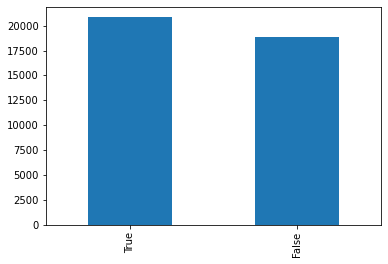

```python
train_y['radiant_win'].value_counts().plot(kind='bar')
```

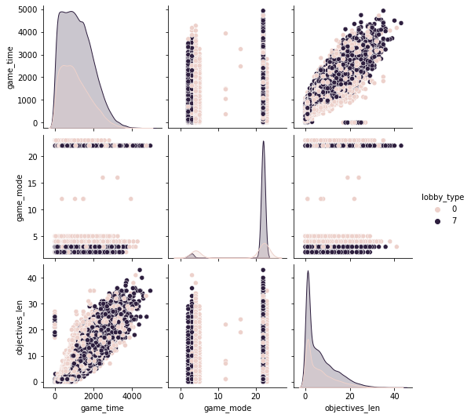

```python
sns.pairplot(train_data.iloc[:,:4], hue='lobby_type')
```

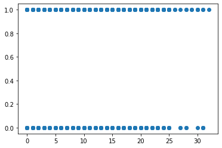

```python
plt.scatter(train_data['r1_kills'], train_y['radiant_win'])
# plot.scatter(x_2, y)
```

### Data Description

```python
display(train_data.head())
train_data.shape
```

| match_id_hash | game_time | game_mode | lobby_type | objectives_len | chat_len | r1_hero_id | r1_kills | r1_deaths | r1_assists | r1_denies | ... | d5_stuns | d5_creeps_stacked | d5_camps_stacked | d5_rune_pickups | d5_firstblood_claimed | d5_teamfight_participation | d5_towers_killed | d5_roshans_killed | d5_obs_placed | d5_sen_placed |
| --- | --- | --- | --- | --- | --- | --- | --- | --- | --- | --- | --- | --- | --- | --- | --- | --- | --- | --- | --- | --- | --- |
| a400b8f29dece5f4d266f49f1ae2e98a | 155 | 22 | 7 | 1 | 11 | 11 | 0 | 0 | 0 | 0 | ... | 0.000000 | 0 | 0 | 0 | 0 | 0.00 | 0 | 0 | 0 | 0 |
| b9c57c450ce74a2af79c9ce96fac144d | 658 | 4 | 0 | 3 | 10 | 15 | 7 | 2 | 0 | 7 | ... | 0.000000 | 0 | 0 | 0 | 0 | 0.00 | 0 | 0 | 0 | 0 |
| 6db558535151ea18ca70a6892197db41 | 21 | 23 | 0 | 0 | 0 | 101 | 0 | 0 | 0 | 0 | ... | 0.000000 | 0 | 0 | 0 | 0 | 0.00 | 0 | 0 | 0 | 0 |
| 46a0ddce8f7ed2a8d9bd5edcbb925682 | 576 | 22 | 7 | 1 | 4 | 14 | 1 | 0 | 3 | 1 | ... | 8.664527 | 3 | 1 | 3 | 0 | 0.00 | 0 | 0 | 2 | 0 |
| b1b35ff97723d9b7ade1c9c3cf48f770 | 453 | 22 | 7 | 1 | 3 | 42 | 0 | 1 | 1 | 0 | ... | 0.000000 | 2 | 1 | 2 | 0 | 0.25 | 0 | 0 | 0 | 0 |

5 rows × 245 columns

```
(39675, 245)
```

The dataset contains 39675 rows and 245 columns/features.  
There are 10 different players (2 teams with 5 players each)  
24 unique columns/features per player (240 columns/features for all players)

The description of each player-feature is given in the following table.[[6]](https://dota2.fandom.com/wiki/Dota_2_Wiki)

| Feature | Description |
| --- | --- |
| **hero_id** | ID of player's hero (int64). Heroes are the essential element of Dota 2, as the course of the match is dependent on their intervention. During a match, two opposing teams select five out of 117 heroes… |
| **kills** | Number of killed players (int64). |
| **deaths** | Number of deaths of the player (int64). |
| **gold** | Amount of gold (int64). Gold is the currency used to buy items or instantly revive your hero. Gold can be earned from killing heroes, creeps, or buildings. |
| **xp** | Experience points (int64). Experience is an element heroes can gather by killing enemy units, or being present as enemy units get killed. On its own, experience does nothing, but when accumulated, it … |
| **lh** | Number of last hits (int64). Last-hitting is a technique where you (or a creep under your control) get the 'last hit' on a neutral creep, enemy lane creep, or enemy hero. The hero that dealt the killi… |
| **denies** | Number of denies (int64). Denying is the act of preventing enemy heroes from getting the last hit on a friendly unit by last hitting the unit oneself. Enemies earn reduced experience if the denied uni… |
| **assists** | Number of [assists](https://dota2.gamepedia.com/Gold#Assists_.28AoE_gold.29) (int64). Allied heroes within 1300 radius of a killed enemy, including the killer, receive experience and reliable gold if … |
| **health** | Health points (int64). Health represents the life force of a unit. When a unit's current health reaches 0, it dies. Every hero has a base health pool of 200. This value exists for all heroes and canno… |
| **max_health** | Hero's maximum health pool (int64). |
| **max_mana** | Hero's maximum mana pool (float64). Mana represents the magic power of a unit. It is used as a cost for the majority of active and even some passive abilities. Every hero has a base mana pool of 75, w… |
| **level** | [Level](https://dota2.gamepedia.com/Experience#Leveling) of player's hero (int64). Each hero begins at level 1, with one free ability point to spend. Heroes may level up by acquiring certain amounts o… |
| **x** | Player's X coordinate (int64) |
| **y** | Player's Y coordinate (int64) |
| **stuns** | Total stun duration of all stuns (float64). Stun is a status effect that completely locks down affected units, disabling almost all of its capabilities. |
| **creeps_stacked** | Number of stacked creeps (int64). [Creep Stacking](https://dota2.gamepedia.com/Creep_Stacking) is the process of drawing neutral creeps away from their camps in order to increase the number of units i… |
| **camps_stacked** | Number of stacked camps (int64). |
| **rune_pickups** | Number of picked up [runes](https://dota2.gamepedia.com/Runes) (int64). |
| **firstblood_claimed** | boolean feature? (int64) |
| **teamfight_participation** | Team fight participation rate? (float64) |
| **towers_killed** | Number of killed/destroyed Towers (int64). Towers are the main line of defense for both teams, attacking any non-neutral enemy that gets within their range. Both factions have all three lanes guarded … |
| **roshans_killed** | Number of killed Roshans (int64). Roshan is the most powerful neutral creep in Dota 2. It is the first unit which spawns, right as the match is loaded. During the early to mid game, he easily outmatch… |
| **obs_placed** | Number of observer-wards placed by a player (int64). [Observer Ward](https://dota2.gamepedia.com/Observer_Ward), an invisible watcher that gives ground vision in a 1600 radius to your team. Lasts 6 mi… |
| **sen_placed** | Number of sentry-wards placed by a player (int64) [Sentry Ward](https://dota2.gamepedia.com/Sentry_Ward), an invisible watcher that grants True Sight, the ability to see invisible enemy units and ward… |

## Data Cleaning

```python
train_data.info()
```

```
<class 'pandas.core.frame.DataFrame'>
Index: 39675 entries, a400b8f29dece5f4d266f49f1ae2e98a to 9928dfde50efcbdb2055da23dcdbc101
Columns: 245 entries, game_time to d5_sen_placed
dtypes: float64(30), int64(215)
memory usage: 74.5+ MB
```

```python
train_data.describe()
```

|  | game_time | game_mode | lobby_type | objectives_len | chat_len | r1_hero_id | r1_kills | r1_deaths | r1_assists | r1_denies | ... | d5_stuns | d5_creeps_stacked | d5_camps_stacked | d5_rune_pickups | d5_firstblood_claimed | d5_teamfight_participation | d5_towers_killed | d5_roshans_killed | d5_obs_placed | d5_sen_placed |
| --- | --- | --- | --- | --- | --- | --- | --- | --- | --- | --- | --- | --- | --- | --- | --- | --- | --- | --- | --- | --- | --- |
| count | 39675.000000 | 39675.000000 | 39675.000000 | 39675.000000 | 39675.000000 | 39675.000000 | 39675.000000 | 39675.000000 | 39675.000000 | 39675.000000 | ... | 39675.000000 | 39675.000000 | 39675.000000 | 39675.000000 | 39675.000000 | 39675.000000 | 39675.000000 | 39675.000000 | 39675.000000 | 39675.000000 |
| mean | 1146.082798 | 19.584776 | 4.772350 | 6.524865 | 7.338500 | 51.103138 | 3.147876 | 3.268809 | 4.670170 | 6.289628 | ... | 11.773324 | 1.039017 | 0.343138 | 4.683907 | 0.090132 | 0.415961 | 0.299811 | 0.024423 | 1.269288 | 0.783289 |
| std | 767.206621 | 6.304976 | 3.260582 | 6.492107 | 13.366381 | 34.603057 | 3.724282 | 3.283323 | 5.225349 | 8.203957 | ... | 20.578321 | 3.534302 | 0.963734 | 4.643219 | 0.286375 | 0.267551 | 0.732490 | 0.170500 | 2.597549 | 2.437952 |
| min | 0.000000 | 2.000000 | 0.000000 | 0.000000 | 0.000000 | 1.000000 | 0.000000 | 0.000000 | 0.000000 | 0.000000 | ... | -6.191284 | 0.000000 | 0.000000 | 0.000000 | 0.000000 | 0.000000 | 0.000000 | 0.000000 | 0.000000 | 0.000000 |
| 25% | 521.000000 | 22.000000 | 0.000000 | 1.000000 | 0.000000 | 20.000000 | 0.000000 | 1.000000 | 1.000000 | 1.000000 | ... | 0.000000 | 0.000000 | 0.000000 | 1.000000 | 0.000000 | 0.236842 | 0.000000 | 0.000000 | 0.000000 | 0.000000 |
| 50% | 1044.000000 | 22.000000 | 7.000000 | 4.000000 | 3.000000 | 44.000000 | 2.000000 | 2.000000 | 3.000000 | 3.000000 | ... | 1.505127 | 0.000000 | 0.000000 | 3.000000 | 0.000000 | 0.444444 | 0.000000 | 0.000000 | 0.000000 | 0.000000 |
| 75% | 1656.000000 | 22.000000 | 7.000000 | 10.000000 | 9.000000 | 81.000000 | 5.000000 | 5.000000 | 7.000000 | 9.000000 | ... | 16.029575 | 0.000000 | 0.000000 | 7.000000 | 0.000000 | 0.600000 | 0.000000 | 0.000000 | 1.000000 | 0.000000 |
| max | 4933.000000 | 23.000000 | 7.000000 | 43.000000 | 291.000000 | 120.000000 | 32.000000 | 27.000000 | 40.000000 | 84.000000 | ... | 277.618070 | 132.000000 | 29.000000 | 57.000000 | 1.000000 | 2.000000 | 9.000000 | 5.000000 | 26.000000 | 47.000000 |

8 rows × 245 columns

```python
# too long to print preview
# for cols in train_data.columns:
#     print(train_data[cols].value_counts().head())
```

```python
train_data.isnull().sum()
```

```
game_time                     0
game_mode                     0
lobby_type                    0
objectives_len                0
chat_len                      0
                             ..
d5_teamfight_participation    0
d5_towers_killed              0
d5_roshans_killed             0
d5_obs_placed                 0
d5_sen_placed                 0
Length: 245, dtype: int64
```

```python
train_data.drop_duplicates()
```

| match_id_hash | game_time | game_mode | lobby_type | objectives_len | chat_len | r1_hero_id | r1_kills | r1_deaths | r1_assists | r1_denies | ... | d5_stuns | d5_creeps_stacked | d5_camps_stacked | d5_rune_pickups | d5_firstblood_claimed | d5_teamfight_participation | d5_towers_killed | d5_roshans_killed | d5_obs_placed | d5_sen_placed |
| --- | --- | --- | --- | --- | --- | --- | --- | --- | --- | --- | --- | --- | --- | --- | --- | --- | --- | --- | --- | --- | --- |
| a400b8f29dece5f4d266f49f1ae2e98a | 155 | 22 | 7 | 1 | 11 | 11 | 0 | 0 | 0 | 0 | ... | 0.000000 | 0 | 0 | 0 | 0 | 0.0000 | 0 | 0 | 0 | 0 |
| b9c57c450ce74a2af79c9ce96fac144d | 658 | 4 | 0 | 3 | 10 | 15 | 7 | 2 | 0 | 7 | ... | 0.000000 | 0 | 0 | 0 | 0 | 0.0000 | 0 | 0 | 0 | 0 |
| 6db558535151ea18ca70a6892197db41 | 21 | 23 | 0 | 0 | 0 | 101 | 0 | 0 | 0 | 0 | ... | 0.000000 | 0 | 0 | 0 | 0 | 0.0000 | 0 | 0 | 0 | 0 |
| 46a0ddce8f7ed2a8d9bd5edcbb925682 | 576 | 22 | 7 | 1 | 4 | 14 | 1 | 0 | 3 | 1 | ... | 8.664527 | 3 | 1 | 3 | 0 | 0.0000 | 0 | 0 | 2 | 0 |
| b1b35ff97723d9b7ade1c9c3cf48f770 | 453 | 22 | 7 | 1 | 3 | 42 | 0 | 1 | 1 | 0 | ... | 0.000000 | 2 | 1 | 2 | 0 | 0.2500 | 0 | 0 | 0 | 0 |
| ... | ... | ... | ... | ... | ... | ... | ... | ... | ... | ... | ... | ... | ... | ... | ... | ... | ... | ... | ... | ... | ... |
| defd0caeed6ea83d7d5fbdec013fe7d1 | 1783 | 22 | 0 | 8 | 23 | 3 | 1 | 9 | 9 | 0 | ... | 26.493834 | 6 | 2 | 3 | 0 | 0.5625 | 0 | 0 | 7 | 2 |
| bc7a87ed5f9c2bca55f9f7a93da0b0c5 | 377 | 22 | 7 | 1 | 0 | 14 | 0 | 2 | 1 | 1 | ... | 0.000000 | 0 | 0 | 1 | 0 | 0.0000 | 0 | 0 | 0 | 0 |
| e2ca68ac1a6847f4a37f6c9c8ee8695b | 643 | 22 | 7 | 1 | 23 | 63 | 1 | 4 | 0 | 2 | ... | 2.532715 | 0 | 0 | 3 | 1 | 0.5000 | 0 | 0 | 1 | 0 |
| 47ad6454ede66c1c78fdaa9391dfc556 | 2405 | 22 | 7 | 12 | 4 | 22 | 3 | 8 | 14 | 7 | ... | 17.583984 | 3 | 1 | 4 | 0 | 0.6250 | 0 | 0 | 0 | 0 |
| 9928dfde50efcbdb2055da23dcdbc101 | 1775 | 22 | 0 | 10 | 13 | 32 | 3 | 4 | 15 | 0 | ... | 8.331238 | 0 | 0 | 1 | 0 | 0.5500 | 1 | 0 | 0 | 0 |

39675 rows × 245 columns

## Exploratory Data Analysis

```python
print(f'Number of samples in train: {train_data.shape[0]}')
print(f'Number of columns in train: {train_data.shape[1]}')
for col in train_data.columns:
    if train_data[col].isnull().any():
        print(col, train_data[col].isnull().sum())
```

```
Number of samples in train: 39675
Number of columns in train: 245
```

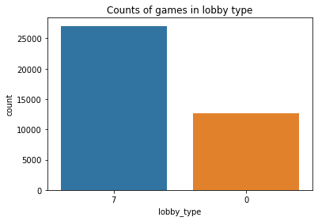

```python
sns.countplot(data=train_data, x='lobby_type', order=train_data['lobby_type'].value_counts().index);
plt.title('Counts of games in lobby type');
```

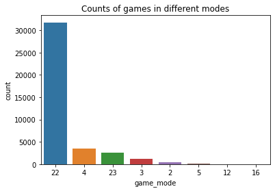

```python
sns.countplot(data=train_data, x='game_mode',
              order=train_data['game_mode'].value_counts().index)
plt.title('Counts of games in different modes')
plt.show()
# will only use the game mode with the most counts of games
```

**Insight**

- Diffent lobby_type and game_modes have different criterias hence, will only choose the lobby_type and game_mode will highest count to make the datapoints balanced.

## Data Preprocessing

### Feature Transformation

```python
# remove lobby_type with lower counts
train_y['lobby_type'] = train_data['lobby_type']
train_data = train_data[train_data['lobby_type'] == 7]
test_data = test_data[test_data['lobby_type'] == 7]
train_y = train_y[train_y['lobby_type'] == 7]

# remove game_mode with lower counts
train_y['game_mode'] = train_data['game_mode']
train_data = train_data[train_data['game_mode'] == 22]
test_data = test_data[test_data['game_mode'] == 22]
train_y = train_y[train_y['game_mode'] == 22]
# drop lobby_type and game_mode for train_y
train_y = train_y.drop(columns=['lobby_type', 'game_mode'])
# mapping win and lose values
train_y = train_y['radiant_win'].map({True: 1, False:0})
```

```python
train_y
```

```
match_id_hash
a400b8f29dece5f4d266f49f1ae2e98a    0
46a0ddce8f7ed2a8d9bd5edcbb925682    1
b1b35ff97723d9b7ade1c9c3cf48f770    0
19c39fe2af2b547e48708ca005c6ae74    0
156c88bff4e9c4668b0f53df3d870f1b    0
                                   ..
71aa1b3585ead73ef3d09e435e454df5    1
06e2b42495855647830ccc6d466f913c    0
bc7a87ed5f9c2bca55f9f7a93da0b0c5    1
e2ca68ac1a6847f4a37f6c9c8ee8695b    0
47ad6454ede66c1c78fdaa9391dfc556    1
Name: radiant_win, Length: 25795, dtype: int64
```

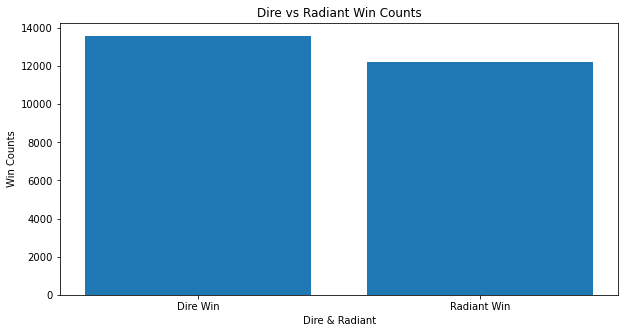

```python
fig, ax = plt.subplots(figsize=(10, 5))
plt.bar(train_y.reset_index()['radiant_win'].unique(),
        train_y.value_counts().values)
plt.xticks([0, 1], labels=['Dire Win', 'Radiant Win'])
plt.xlabel('Dire & Radiant')
plt.ylabel('Win Counts')
plt.title('Dire vs Radiant Win Counts')
plt.show()
# the distribution is balanced
```

### Feature Engineering

```python
# combing all individual character features into a team based features
feature_names = train_data.columns
num = []
for y in range(24):
    for i in [feature_names[feature_names.str.contains("r"+str(i)) == True] for i in range(1,6)]:
        num.append(i[y])
    col = num[0].split("_")[1]
    train_data['r_'+col] = train_data[num].sum(axis=1)
    test_data['r_'+col] = test_data[num].sum(axis=1)

    # dropping individual features
    train_data.drop(columns=num, inplace=True)
    test_data.drop(columns=num, inplace=True)
    num = []

for y in range(24):
    for i in [feature_names[feature_names.str.contains("d"+str(i)) == True] for i in range(1,6)]:
        num.append(i[y])
    col = num[0].split("_")[1]
    train_data['d_'+col] = train_data[num].sum(axis=1)
    test_data['d_'+col] = test_data[num].sum(axis=1)

    # dropping individual features
    train_data.drop(columns=num, inplace=True)
    test_data.drop(columns=num, inplace=True)
    num = []
```

### Feature Selection

```python
# what features to be used
to_load = (['r_kills', 'r_deaths', 'r_assists', 'r_denies', 'r_lh', 'r_gold',
            'd_kills', 'd_deaths', 'd_assists', 'd_denies', 'd_lh', 'd_gold'])
train_X = train_data[to_load]
test_X = test_data[to_load]

# reduced the datapoints for the interest of runtime and
# to show the significance of the models
feature_names = train_X.columns
train_sample = int(train_X.shape[0]/2)
test_sample = int(test_X.shape[0]/2)

# getting sample size
train_X = train_X.sample(train_sample, random_state=3)
train_y = train_y.sample(train_sample, random_state=3)
test_X = test_X.sample(test_sample, random_state=3)
train_X
```

| match_id_hash | r_kills | r_deaths | r_assists | r_denies | r_lh | r_gold | d_kills | d_deaths | d_assists | d_denies | d_lh | d_gold |
| --- | --- | --- | --- | --- | --- | --- | --- | --- | --- | --- | --- | --- |
| 51935e6a7ebc00bcfe6b8d082d5d232b | 41 | 30 | 74 | 38 | 486 | 69141 | 28 | 48 | 49 | 31 | 434 | 53622 |
| 57455963101b07a93742832c85264d9c | 25 | 31 | 37 | 44 | 685 | 64263 | 29 | 26 | 48 | 63 | 736 | 69192 |
| e22f75d86fba5083613909fb8dd672eb | 12 | 12 | 7 | 22 | 261 | 21744 | 12 | 12 | 17 | 35 | 171 | 20638 |
| 350046f4953aeeafaf056bba08ed86bc | 14 | 15 | 21 | 26 | 365 | 31474 | 15 | 14 | 20 | 53 | 371 | 32895 |
| 740655b7eb302734079c6337593367ff | 7 | 19 | 4 | 15 | 365 | 26465 | 18 | 7 | 34 | 53 | 298 | 32690 |
| ... | ... | ... | ... | ... | ... | ... | ... | ... | ... | ... | ... | ... |
| 453fee86e524027db9c61f610e14c015 | 56 | 41 | 91 | 34 | 1002 | 112884 | 40 | 59 | 48 | 44 | 974 | 105108 |
| a7ac25a94aeea637efba990391deef45 | 18 | 39 | 31 | 31 | 463 | 45829 | 38 | 18 | 51 | 39 | 578 | 63543 |
| 70dcb4899429f01a69e28f1ff4dffe1c | 39 | 29 | 54 | 47 | 935 | 104845 | 28 | 40 | 48 | 45 | 866 | 79331 |
| 690dcdfdc057058f0498d0693bb3c7e5 | 21 | 18 | 22 | 44 | 376 | 38486 | 18 | 21 | 26 | 16 | 308 | 30739 |
| 39e95ecce4328b93573f0d90a9af3919 | 3 | 13 | 4 | 25 | 102 | 11081 | 12 | 4 | 0 | 19 | 185 | 16960 |

12897 rows × 12 columns

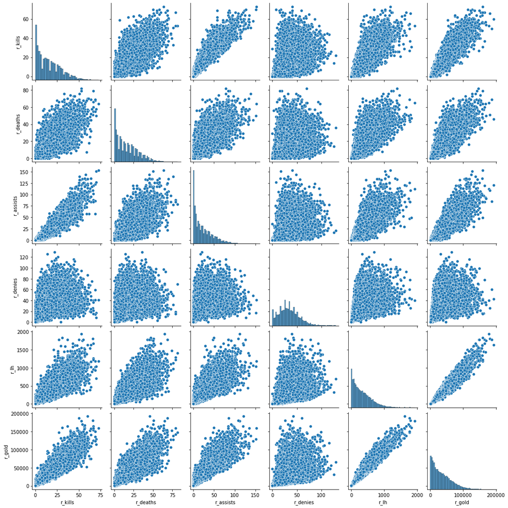

```python
sns.pairplot(train_X.iloc[:,:6])
plt.show()
```

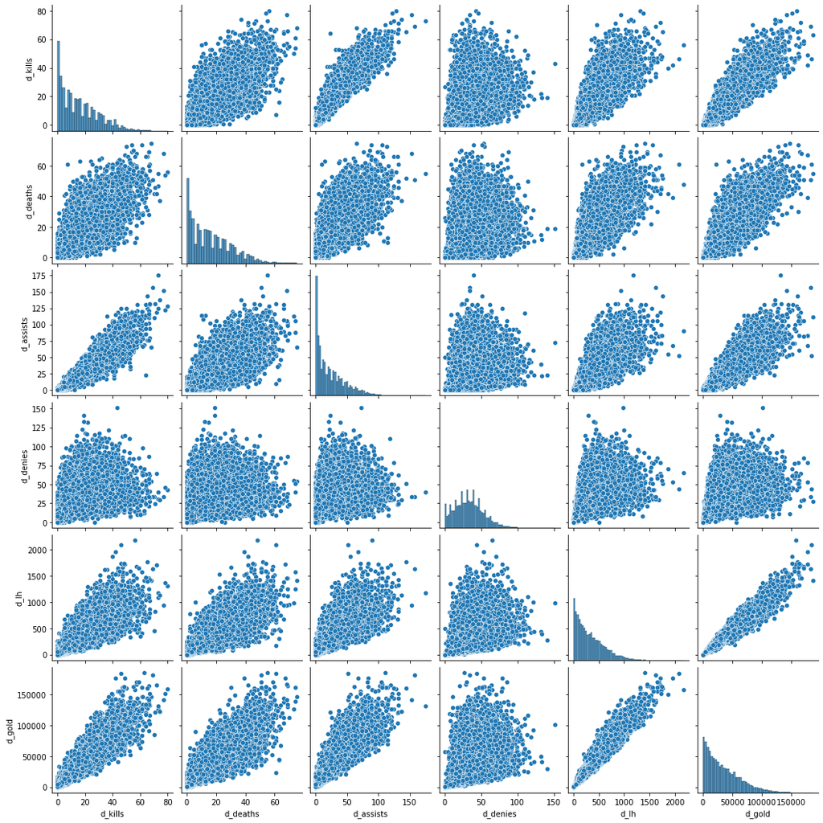

```python
sns.pairplot(train_X.iloc[:,6:])
plt.show()
```

### Data Scaling

```python
# Scaling
scaler = StandardScaler()
train_X_scaled = scaler.fit_transform(train_X)
test_X_scaled = scaler.fit_transform(test_X)
```

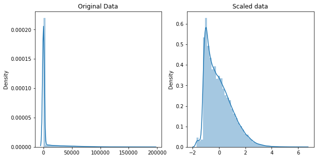

```python
fig, ax=plt.subplots(1,2, figsize=(10,5))
sns.distplot(train_X, ax=ax[0])
ax[0].set_title("Original Data")
sns.distplot(train_X_scaled, ax=ax[1])
ax[1].set_title("Scaled data")
plt.show()
```

## Final Data

```python
# scaled data
train_X_scaled # for train value
test_X_scaled # for test value

# original data
train_X # for train value
test_X # for test value

# output to csv
train_X.to_csv('train_X.csv')
test_X.to_csv('test_X.csv')
train_y.to_csv('train_y.csv')
```

# Results and Discussion

## Auto ML Simulation

```
Training and testing: kNN model
```

```
Training and testing: Logistic (L1) model
```

```
Training and testing: Logistic (L2) model
```

```
Training and testing: Decision Tree model
```

```
Training and testing: RF Classifier model
```

```
Training and testing: GB Classifier model
```

```
Training and testing: XGB Classifier model
```

```
Training and testing: AdaBoost DT model
```

```
Training and testing: LightGBM Classifier model
```

```
Training and testing: CatBoost Classifier model
```

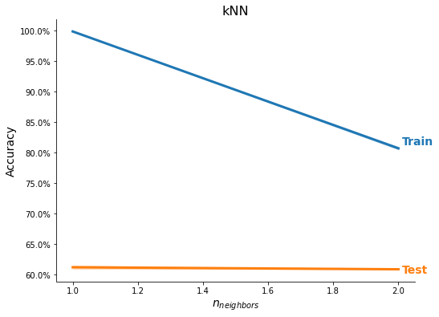

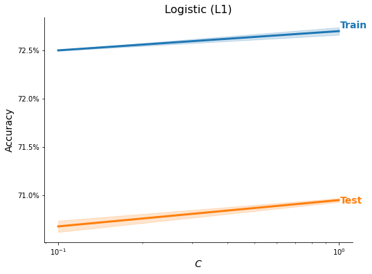

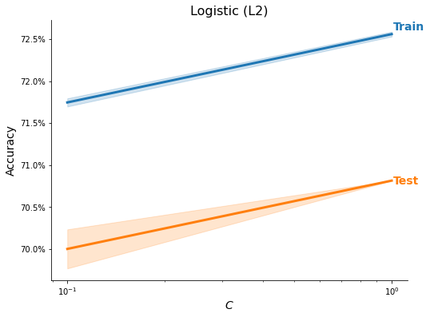

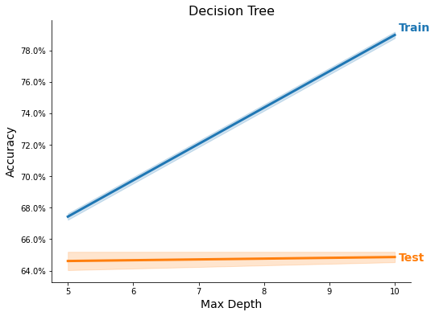

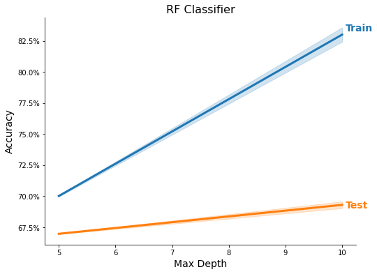

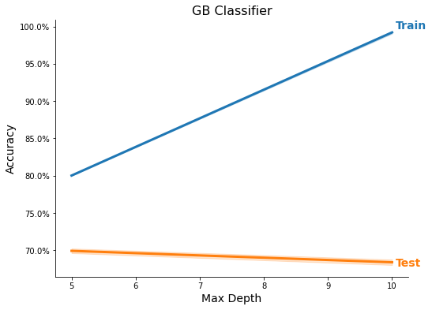

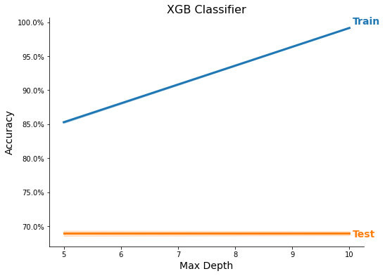

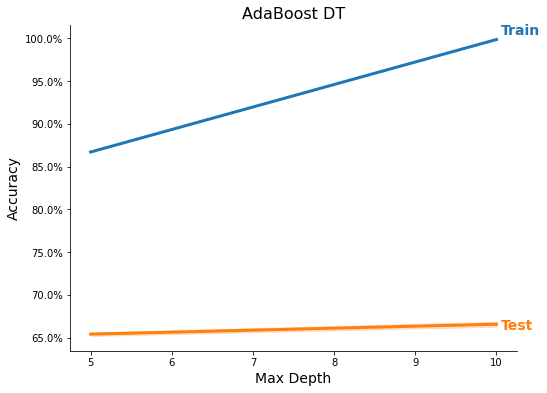

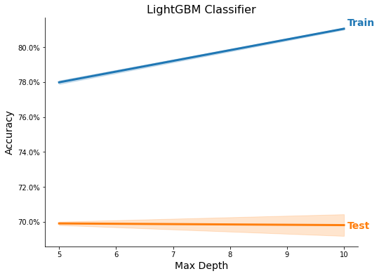

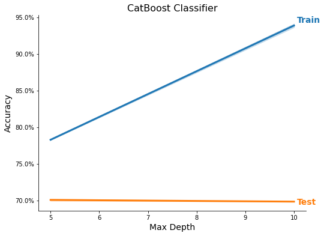

[output not shown]

```python
# Select methods
methods = ['kNN', 'Logistic (L1)', 'Logistic (L2)', 'Decision Tree',
           'RF Classifier', 'GB Classifier', 'XGB Classifier',
           'AdaBoost DT', 'LightGBM Classifier', 'CatBoost Classifier']

# Perform training and testing
ml_models = MLModels.run_classifier(
    train_X_scaled, train_y, feature_names, task='C',
    use_methods=methods, n_trials=2, tree_rs=3, test_size=0.20,
    n_neighbors=list(range(1, 3)),
    C=[1e-1, 1],
    max_depth=[5, 10])
res = MLModels.summarize(ml_models, feature_names,
                         show_plot=True, show_top=True)
```

## Feature Importance

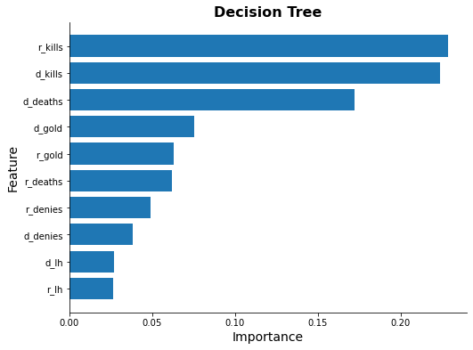

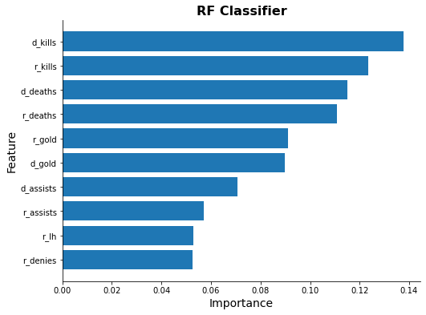

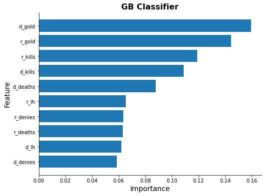

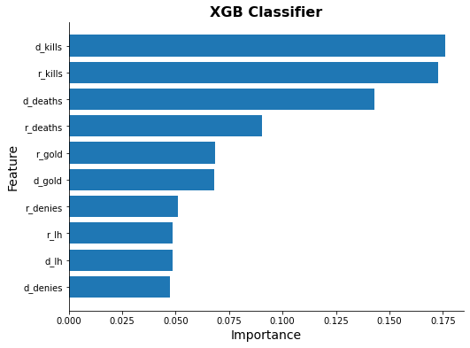

[figure not shown]

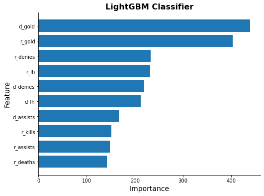

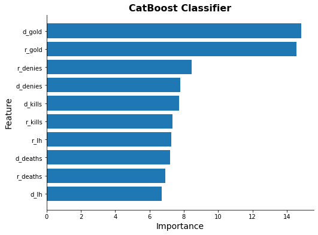

```python
for model_name in methods[3:]:
    try:
        ax = ml_models[model_name].plot_feature_importance(feature_names)
        ax.set_title(model_name, fontsize=16, weight="bold")
    except Exception as e:
        print(model_name, e)
```

## Light GBM Classifier Simulation

```python
# reduced params range based from previous multiple trials
tune_model(train_X_scaled, train_y, 'Classification', 'LightGBM Classifier',
           params={'max_depth': [25, 50],
                   'n_estimators': [150, 200],
                   'learning_rate': [0.1, 0.2]},
           n_trials=2, tree_rs=3)
```

```
params:{'max_depth': 25, 'n_estimators': 150, 'learning_rate': 0.1} 	score: 0.691163	std: 0.002481
```

```
params:{'max_depth': 25, 'n_estimators': 200, 'learning_rate': 0.1} 	score: 0.694109	std: 0.001395
```

```
{'Model': 'LightGBM Classifier',
 'Accuracy': '69.41%',
 'Best Parameter': {'max_depth': 25,
  'n_estimators': 200,
  'learning_rate': 0.1},
 'Classifier': LGBMClassifier(max_depth=25, n_estimators=200, random_state=3),
 'acc': 69.41,
 'std': 0.0013953488372092648}
```

## Bayesian Optimization Simulation

Used only 3 parameters to optimized to show how bayesian optimization optimize a function, hence bayesian optimization is a function optimization package[[7]](https://github.com/fmfn/BayesianOptimization)

### The function to be optimized

```python
def lgb_cv(num_leaves, max_depth, min_data_in_leaf):
    params = {
        "num_leaves": int(num_leaves),
        "max_depth": int(max_depth),
        "learning_rate": 0.5,
        'min_data_in_leaf': int(min_data_in_leaf),
        "force_col_wise": True,
        'verbose': -1,
        "metric" : "auc",
        "objective" : "binary",
    }

    lgtrain = lightgbm.Dataset(train_X_scaled, train_y)
    cv_result = lightgbm.cv(params,
                       lgtrain,
                       200,
                       early_stopping_rounds=200,
                       stratified=True,
                       nfold=5)
    return cv_result['auc-mean'][-1]
```

### The optimizer function

```python
def bayesian_optimizer(init_points, num_iter, **args):
    lgb_BO = BayesianOptimization(lgb_cv, {'num_leaves': (100, 200),
                                           'max_depth': (25, 50),
                                           'min_data_in_leaf': (50, 200)
                                           })
    lgb_BO.maximize(init_points=init_points, n_iter=num_iter, **args)
    return lgb_BO
```

```python
# Simulating all iteration for getting optimized paramters
results = bayesian_optimizer(10,10)
```

```
|   iter    |  target   | max_depth | min_da... | num_le... |
-------------------------------------------------------------
| 1         | 0.7859    | 49.98     | 128.7     | 115.4     |
| 2         | 0.7796    | 42.94     | 68.67     | 190.1     |
| 3         | 0.7784    | 28.36     | 57.48     | 107.0     |
| 4         | 0.7869    | 30.55     | 134.1     | 150.3     |
| 5         | 0.7892    | 36.73     | 162.4     | 187.3     |
| 6         | 0.7866    | 31.26     | 195.5     | 165.7     |
| 7         | 0.7804    | 37.51     | 75.45     | 175.9     |
| 8         | 0.7848    | 45.02     | 123.7     | 153.1     |
| 9         | 0.7842    | 33.06     | 124.2     | 109.2     |
| 10        | 0.7884    | 39.39     | 164.4     | 142.8     |
| 11        | 0.7882    | 39.39     | 165.1     | 143.5     |
| 12        | 0.7881    | 50.0      | 179.0     | 100.0     |
| 13        | 0.7895    | 50.0      | 200.0     | 200.0     |
| 14        | 0.7892    | 25.0      | 186.1     | 200.0     |
| 15        | 0.7882    | 25.0      | 165.9     | 113.4     |
| 16        | 0.7876    | 25.0      | 138.8     | 200.0     |
| 17        | 0.7874    | 50.0      | 169.2     | 200.0     |
| 18        | 0.7895    | 25.0      | 200.0     | 100.0     |
| 19        | 0.7893    | 49.78     | 198.9     | 120.6     |
| 20        | 0.7892    | 26.53     | 198.9     | 121.2     |
=============================================================
```

### Train Iterations with the optimized parameters

```python
def lgb_train(num_leaves, max_depth,  min_data_in_leaf):
    params = {
        "num_leaves": int(num_leaves),
        "max_depth": int(max_depth),
        "learning_rate": 0.5,
        'min_data_in_leaf': int(min_data_in_leaf),
        "force_col_wise": True,
        'verbose': -1,
        "metric": "auc",
        "objective": "binary",
    }

    x_train, x_val, y_train, y_val = train_test_split(
        train_X_scaled, train_y, test_size=0.2, random_state=3)
    lgtrain = lightgbm.Dataset(x_train, y_train)
    lgvalid = lightgbm.Dataset(x_val, y_val)
    model = (lightgbm.train(params, lgtrain, 200, valid_sets=[lgvalid],
                            early_stopping_rounds=200, verbose_eval=False))
    prediction_val = model.predict(
        test_X_scaled, num_iteration=model.best_iteration)
    return prediction_val, model
```